# Análise dos Red Wines por Felipe Sousa Pessina

# Seção de Gráficos Univariados

```
## 'data.frame':    1599 obs. of  14 variables:
##  $ X                   : int  1 2 3 4 5 6 7 8 9 10 ...
##  $ fixed.acidity       : num  7.4 7.8 7.8 11.2 7.4 7.4 7.9 7.3 7.8 7.5 ...
##  $ volatile.acidity    : num  0.7 0.88 0.76 0.28 0.7 0.66 0.6 0.65 0.58 0.5 ...
##  $ citric.acid         : num  0 0 0.04 0.56 0 0 0.06 0 0.02 0.36 ...
##  $ residual.sugar      : num  1.9 2.6 2.3 1.9 1.9 1.8 1.6 1.2 2 6.1 ...
##  $ chlorides           : num  0.076 0.098 0.092 0.075 0.076 0.075 0.069 0.065 0.073 0.071 ...
##  $ free.sulfur.dioxide : num  11 25 15 17 11 13 15 15 9 17 ...
##  $ total.sulfur.dioxide: num  34 67 54 60 34 40 59 21 18 102 ...
##  $ density             : num  0.998 0.997 0.997 0.998 0.998 ...
##  $ pH                  : num  3.51 3.2 3.26 3.16 3.51 3.51 3.3 3.39 3.36 3.35 ...
##  $ sulphates           : num  0.56 0.68 0.65 0.58 0.56 0.56 0.46 0.47 0.57 0.8 ...
##  $ alcohol             : num  9.4 9.8 9.8 9.8 9.4 9.4 9.4 10 9.5 10.5 ...
##  $ quality             : int  5 5 5 6 5 5 5 7 7 5 ...
##  $ quality.factor      : Factor w/ 5 levels "InvalidNegative",..: 3 3 3 4 3 3 3 4 4 3 ...
```

O banco de dados que iremos analisar é composto por 13 variáveis sendo uma delas o index, com 1599 observações sobre os dados dos vinhdos. Nosos objetivo com esta análise é verificar quais variáveis influenciam fortemente na qualidade do vinhdo, e também se é possível prever a qualidade. Vamos primeiro analisar a distribuição das notas de qualidade dos vinhos.

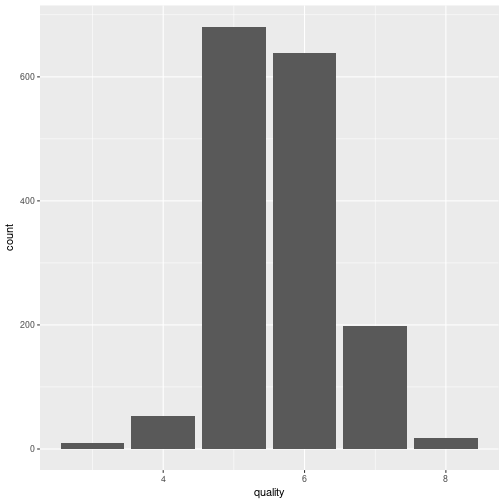

```
##    Min. 1st Qu.  Median    Mean 3rd Qu.    Max.
##   3.000   5.000   6.000   5.636   6.000   8.000
```

Sabemos que as notas de qualidade dos vinhos variam de 0 a 10, porém como podemos ver na tabela, a nota mínima encontrada foi o valor 3 e a máxima de 8. Outro dado a destacar, é que a maioria dos vinhos se concentram na notas 5 e 6, tornando difícil encontrar um vinho de ótima e outro de péssima qualidade em nossa amostra

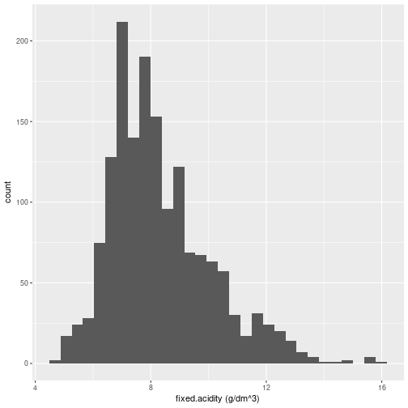

```
##    Min. 1st Qu.  Median    Mean 3rd Qu.    Max.
##    4.60    7.10    7.90    8.32    9.20   15.90
```

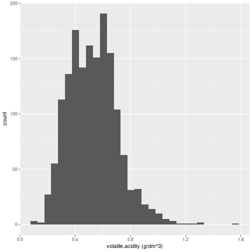

```
##    Min. 1st Qu.  Median    Mean 3rd Qu.    Max.
##  0.1200  0.3900  0.5200  0.5278  0.6400  1.5800
```

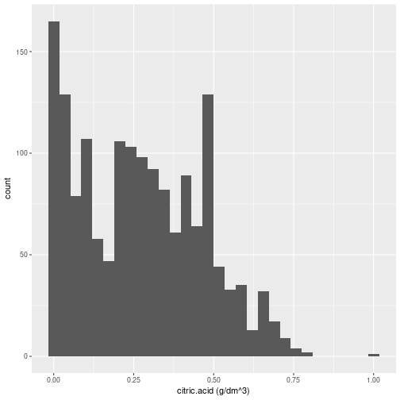

```
##    Min. 1st Qu.  Median    Mean 3rd Qu.    Max.
##   0.000   0.090   0.260   0.271   0.420   1.000
```

Temos acima os gráficos de distribuição da concentração do ácido tartárico (fixed), acético (volatile) e cítrico (citric), em g/dm<sup>3.</sup> As distribuições do ácido tartárico e acético, se assemelham muito mais com uma distribuição normal, do que o cítrico, que apresenta dois intervalos com frequência altas

Um fato curioso observado para os valores da concentração do ácido cítrico é a grande quantidade de valores no intervalo que abrange o valor zero, vamos verificar qual a contagem para cada valor.

```
##
##    0 0.01 0.02 0.03 0.04 0.05 0.06 0.07 0.08 0.09  0.1 0.11 0.12 0.13 0.14
##  132   33   50   30   29   20   24   22   33   30   35   15   27   18   21
## 0.15 0.16 0.17 0.18 0.19  0.2 0.21 0.22 0.23 0.24 0.25 0.26 0.27 0.28 0.29
##   19    9   16   22   21   25   33   27   25   51   27   38   20   19   21
##  0.3 0.31 0.32 0.33 0.34 0.35 0.36 0.37 0.38 0.39  0.4 0.41 0.42 0.43 0.44
##   30   30   32   25   24   13   20   19   14   28   29   16   29   15   23
## 0.45 0.46 0.47 0.48 0.49  0.5 0.51 0.52 0.53 0.54 0.55 0.56 0.57 0.58 0.59
##   22   19   18   23   68   20   13   17   14   13   12    8    9    9    8
##  0.6 0.61 0.62 0.63 0.64 0.65 0.66 0.67 0.68 0.69  0.7 0.71 0.72 0.73 0.74
##    9    2    1   10    9    7   14    2   11    4    2    1    1    3    4
## 0.75 0.76 0.78 0.79    1
##    1    3    1    1    1
```

Como podemos ver na tabela de frequência, o tamanhao da primeira coluna no histograma é consequência da grande quantidade de vinhos com ausência de ácido cítrico ou pode ser que tenhamos problemas nos instrumentos de medição, mas o fato do segundo intervalo apresentar uma frequência alta, me faz acreditar que realmente há vinhos com ausência de ácido cítrico

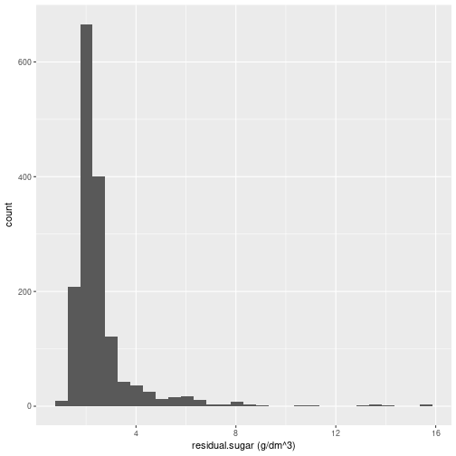

[output not shown]

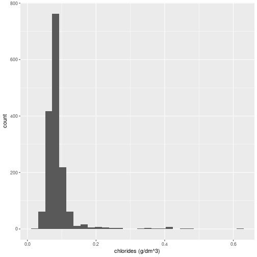

```
##    Min. 1st Qu.  Median    Mean 3rd Qu.    Max.
## 0.01200 0.07000 0.07900 0.08747 0.09000 0.61100
```

Os dois gráficos, tanto para o açucar quanto sal, apresentam frequência altas para os intervalos inciais de concentrações. Porém vemos nos dois histogramas, pequenas colunas em altas concentrações, estes vinhos com altas concentrações provavelmente tiveram problemas em sua fabricação e iremos tratá-los como outliers.

Vamos redesenhar o gráfico focando nas altas frequências

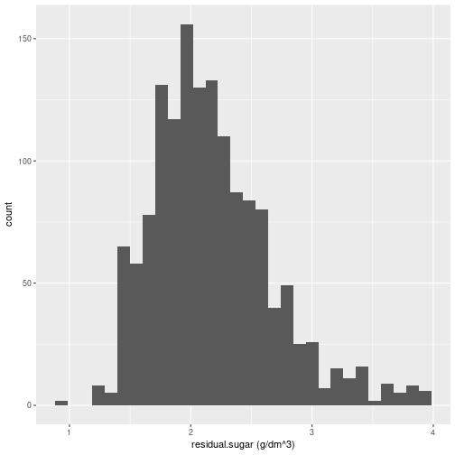

```
##    Min. 1st Qu.  Median    Mean 3rd Qu.    Max.
##   0.900   1.900   2.100   2.201   2.500   3.900
```

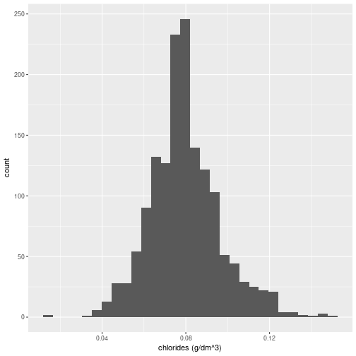

```
##    Min. 1st Qu.  Median    Mean 3rd Qu.    Max.
## 0.01200 0.07000 0.07900 0.07964 0.08800 0.14800
```

Agora podemos ver com mais detalhes as distribuições e elas se assemelham com distribuições normais

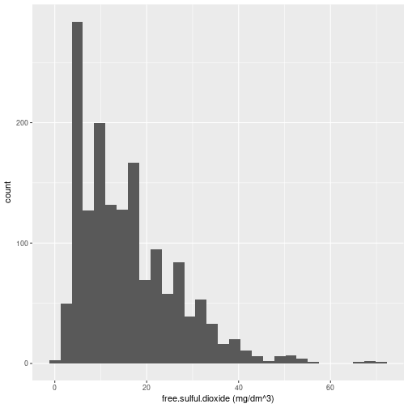

```
##    Min. 1st Qu.  Median    Mean 3rd Qu.    Max.
##    1.00    7.00   14.00   15.87   21.00   72.00
```

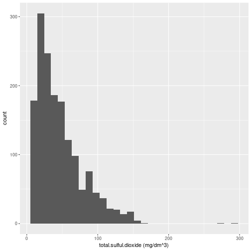

```
##    Min. 1st Qu.  Median    Mean 3rd Qu.    Max.
##    6.00   22.00   38.00   46.47   62.00  289.00
```

Como vemos nenhuma das distribuições do dióxido de enxofre se apresenta como normal, vamos tentar aplicar funções matemáticas para alterar a forma do histograma

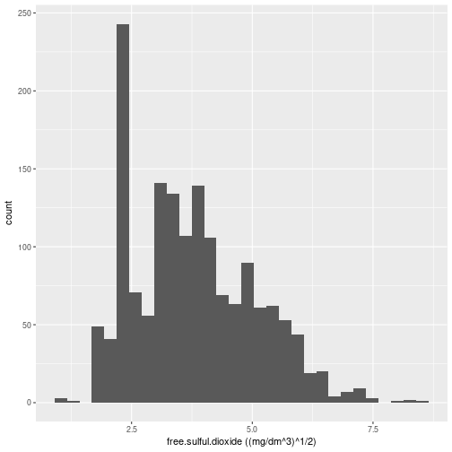

```
##    Min. 1st Qu.  Median    Mean 3rd Qu.    Max.
##   1.000   2.646   3.742   3.781   4.583   8.485
```

```
##
##                1  1.4142135623731 1.73205080756888                2
##                3                1               49               41
## 2.23606797749979 2.34520787991171 2.44948974278318 2.64575131106459
##              104                1              138               71
## 2.82842712474619                3 3.16227766016838  3.3166247903554
##               56               62               79               59
## 3.46410161513775 3.60555127546399 3.74165738677394 3.87298334620742
##               75               57               50               78
##                4 4.12310562561766 4.24264068711928 4.35889894354067
##               61               60               46               39
## 4.47213595499958 4.58257569495584 4.69041575982343 4.79583152331272
##               30               41               22               32
## 4.89897948556636                5 5.09901951359278 5.19615242270663
##               34               24               32               29
## 5.29150262212918  5.3851648071345 5.47722557505166 5.56776436283002
##               23               23               16               20
## 5.65685424949238 5.74456264653803  5.8309518948453 5.91607978309962
##               22               11               18               15
##                6 6.08276253029822 6.12372435695795 6.16441400296898
##               11                3                2                9
##  6.2449979983984 6.32455532033676 6.36396103067893 6.40312423743285
##                5                6                1                7
## 6.48074069840786   6.557438524302 6.70820393249937 6.78232998312527
##                3                3                3                1
## 6.85565460040104 6.92820323027551 7.07106781186548 7.14142842854285
##                1                4                2                4
## 7.21110255092798 7.28010988928052 7.34846922834953 7.41619848709566
##                3                1                1                2
## 7.54983443527075 8.12403840463596 8.24621125123532 8.48528137423857
##                1                1                2                1
```

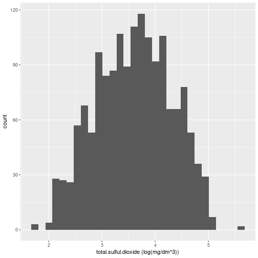

```
##    Min. 1st Qu.  Median    Mean 3rd Qu.    Max.
##   1.792   3.091   3.638   3.601   4.127   5.666
```

O mínimo para as duas distribuuições é diferente de zero, logo podemos aplicar a função log como tentativa de normalizar a distribuição.

O formato da primeira distribuição pode ser melhorado com o uso da raiz quadrada, porém continuamos vendo um pico de valores para 2.236 e 2.449 como vemos na tabela de frequência, tentei aplicar log e raiz cúbica neste gráfico mas não foi possível melhorar a vizulização

O formato da segunda distribuiçao, foi normalizado com o uso da função log

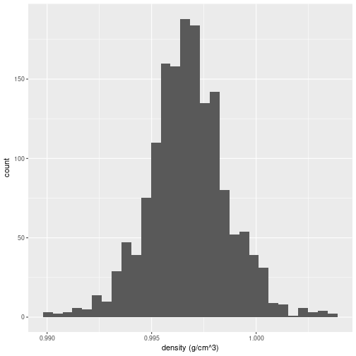

```
##    Min. 1st Qu.  Median    Mean 3rd Qu.    Max.
##  0.9901  0.9956  0.9968  0.9967  0.9978  1.0037
```

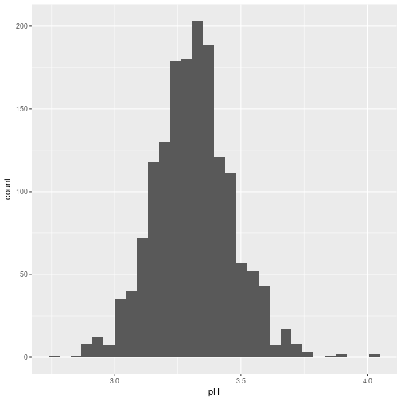

```
##    Min. 1st Qu.  Median    Mean 3rd Qu.    Max.
##   2.740   3.210   3.310   3.311   3.400   4.010
```

Acima vemos que a distribuição de pHs tanto de densidade se apresentam como normais.

Além disto podemos ver também que a toda a distribuição está abaixo do pH 7, ou seja todos os vinhos analisádos são ácidos, este fato deve estar intimamente relacionado com as concentrações dos ácidos, na segunda seção iremos explorar esta relação mais a fundo

Um dado curioso sobre a análise de densidade é que a grande maioria dos vinhos possui densidade menor que 1, ou seja são menos densos que a água.

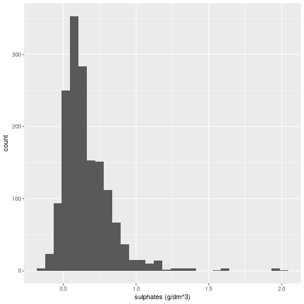

```
##    Min. 1st Qu.  Median    Mean 3rd Qu.    Max.
##  0.3300  0.5500  0.6200  0.6581  0.7300  2.0000
```

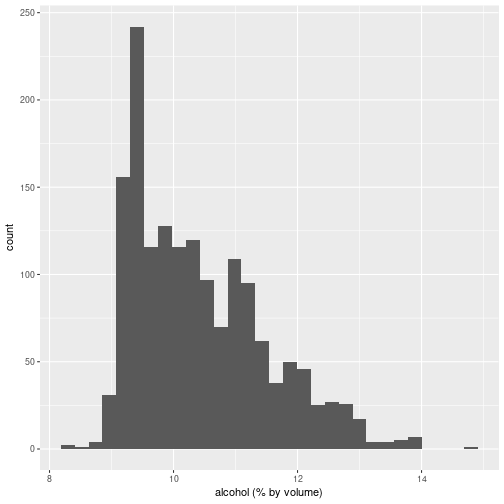

```
##    Min. 1st Qu.  Median    Mean 3rd Qu.    Max.
##    8.40    9.50   10.20   10.42   11.10   14.90
```

Podemos ver a partir do histograma dos sulfatos, que a grande maioria dos vinhos possui baixas concentrações de sulfatos, porém vemos também pequenas colunas em altas concentrações, vamos tratá-los como outliers e reduzir o nosso intervalor de plot

Na distribuição de concentração de alcol, vemos um pico próximo a 9 e que quanto maior o teor alcólico menor é a frequência de vinhos

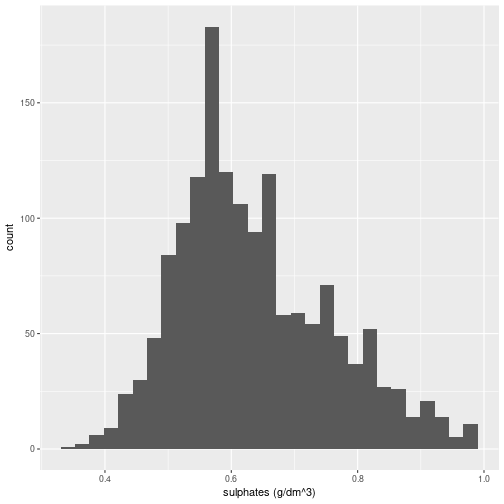

# Análise Univariada

### Qual é a estrutura do conjunto de dados?

Temos 12 variáveis em nosso data frame (fixed.acidity, volatile.acidity, citric.acid, residual.sugar, chlorides, free.sulfur.dioxide, total.sulfur.dioxide, density, pH, sulphates, alcohol, quality) total elas numéricas. E temos 1599 observações de vinhos registradas no conjunto de dados

Algumas observações sobre os dados: -A maioria dos valores de qualidade do vinho estão nos valores 5 e 6 -Os vinhos podem ser separados em 2 grupos de acordo com a concentração de ácido cítrico -A média de açucar residual é 2.201 e a concentração média de sal é 0.0.7964 -O pH médio é 3.311 -A densidade média é 0.9967 -50% dos vinhos tem concentração de alcool no intervalo 9.50 - 11.10

### Quais são os principais atributos de interesse deste conjunto de dados?

As variáveis mais interessantes são o pH, teor alcólico e densidade. Acredito que a segunda tenha uma forte correação com a densidade dos ácidos presentes na amostra, e as duas últimas tenham um correlação com a qualidade do vinho

### Quais outros atributos você acha que podem lhe auxiliar na investigação destes atributos de interesse?

Alguns atributos que acredito que possam também ter influência no pH são as concentrações dos ácidos (tatárico, acético e cítrico). A densidade deve ter uma relação com o alcool e o alcool possivelmente possui relação com açúcar residual.

### Dos atributos investigados, distribuições incomuns foram encontradas? Você aplicou operações nos dados para limpá-los, ajustá-los ou mudar a forma dos dados? Se sim, por quê?

Outras distribuições como o dióxido de enxofre livre e dióxido de enxofre total, não se apresentavam na forma de uma distribuição normal, mas com a aplicação de funções de log e raiz quadradad foi possível melhorar a vizualização para estas variáveis, aproximando-se de uma distribuição normal.

# Seção de Gráficos Bivariados

```
##                      fixed.acidity volatile.acidity citric.acid
## fixed.acidity           1.00000000     -0.256130895  0.67170343
## volatile.acidity       -0.25613089      1.000000000 -0.55249568
## citric.acid             0.67170343     -0.552495685  1.00000000
## residual.sugar          0.11477672      0.001917882  0.14357716
## chlorides               0.09370519      0.061297772  0.20382291
## free.sulfur.dioxide    -0.15379419     -0.010503827 -0.06097813
## total.sulfur.dioxide   -0.11318144      0.076470005  0.03553302
## density                 0.66804729      0.022026232  0.36494718
## pH                     -0.68297819      0.234937294 -0.54190414
## sulphates               0.18300566     -0.260986685  0.31277004
## alcohol                -0.06166827     -0.202288027  0.10990325
## quality                 0.12405165     -0.390557780  0.22637251
##                      residual.sugar    chlorides free.sulfur.dioxide
## fixed.acidity           0.114776724  0.093705186        -0.153794193
## volatile.acidity        0.001917882  0.061297772        -0.010503827
## citric.acid             0.143577162  0.203822914        -0.060978129
## residual.sugar          1.000000000  0.055609535         0.187048995
## chlorides               0.055609535  1.000000000         0.005562147
## free.sulfur.dioxide     0.187048995  0.005562147         1.000000000
## total.sulfur.dioxide    0.203027882  0.047400468         0.667666450
## density                 0.355283371  0.200632327        -0.021945831
## pH                     -0.085652422 -0.265026131         0.070377499
## sulphates               0.005527121  0.371260481         0.051657572
## alcohol                 0.042075437 -0.221140545        -0.069408354
## quality                 0.013731637 -0.128906560        -0.050656057
##                      total.sulfur.dioxide     density          pH
## fixed.acidity                 -0.11318144  0.66804729 -0.68297819
## volatile.acidity               0.07647000  0.02202623  0.23493729
## citric.acid                    0.03553302  0.36494718 -0.54190414
## residual.sugar                 0.20302788  0.35528337 -0.08565242
## chlorides                      0.04740047  0.20063233 -0.26502613
## free.sulfur.dioxide            0.66766645 -0.02194583  0.07037750
## total.sulfur.dioxide           1.00000000  0.07126948 -0.06649456
## density                        0.07126948  1.00000000 -0.34169933
## pH                            -0.06649456 -0.34169933  1.00000000
## sulphates                      0.04294684  0.14850641 -0.19664760
## alcohol                       -0.20565394 -0.49617977  0.20563251
## quality                       -0.18510029 -0.17491923 -0.05773139
##                         sulphates     alcohol     quality
## fixed.acidity         0.183005664 -0.06166827  0.12405165
## volatile.acidity     -0.260986685 -0.20228803 -0.39055778
## citric.acid           0.312770044  0.10990325  0.22637251
## residual.sugar        0.005527121  0.04207544  0.01373164
## chlorides             0.371260481 -0.22114054 -0.12890656
## free.sulfur.dioxide   0.051657572 -0.06940835 -0.05065606
## total.sulfur.dioxide  0.042946836 -0.20565394 -0.18510029
## density               0.148506412 -0.49617977 -0.17491923
## pH                   -0.196647602  0.20563251 -0.05773139
## sulphates             1.000000000  0.09359475  0.25139708
## alcohol               0.093594750  1.00000000  0.47616632
## quality               0.251397079  0.47616632  1.00000000
```

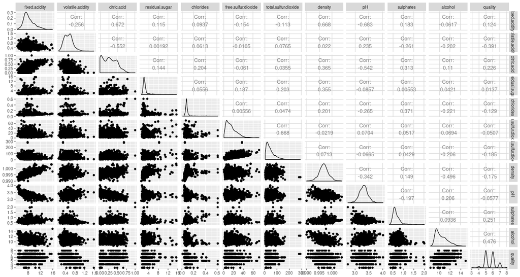

Observando a coluna de coeficientes de correalção de qualidade, não encontramos nenhum superior a 0.7 que nos indicaria uma correalação linear forte entre as duas variáveis. Os dois coeficientes mais fortes encontrados foram com Alcool (0.476) e Ácido Volátil (-0.391), o que me surpreendeu. A minha expectativa era que o pH tivesse grande correlação com a concentração dos ácidos presentes, e também com o qualidade. Porém vemos que o coeficiente de correlação do pH com qualidade é quase nulo, mas um dos ácidos (acético) tem um correlação moderada com a qualidade.

Vamos dar uma olhada em como o teor alcólico e densidade afetam a qualidade

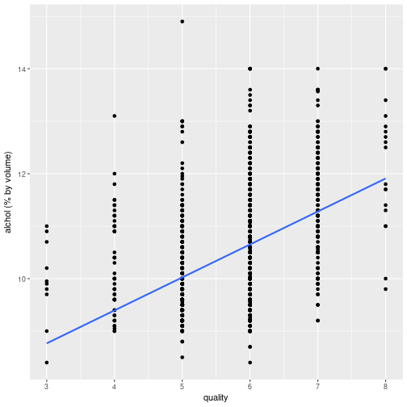

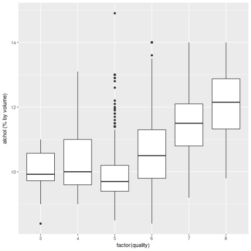

```
## $`3`
##    Min. 1st Qu.  Median    Mean 3rd Qu.    Max.
##   8.400   9.725   9.925   9.955  10.575  11.000
##
## $`4`
##    Min. 1st Qu.  Median    Mean 3rd Qu.    Max.
##    9.00    9.60   10.00   10.27   11.00   13.10
##
## $`5`
##    Min. 1st Qu.  Median    Mean 3rd Qu.    Max.
##     8.5     9.4     9.7     9.9    10.2    14.9
##
## $`6`
##    Min. 1st Qu.  Median    Mean 3rd Qu.    Max.
##    8.40    9.80   10.50   10.63   11.30   14.00
##
## $`7`
##    Min. 1st Qu.  Median    Mean 3rd Qu.    Max.
##    9.20   10.80   11.50   11.47   12.10   14.00
##
## $`8`
##    Min. 1st Qu.  Median    Mean 3rd Qu.    Max.
##    9.80   11.32   12.15   12.09   12.88   14.00
```

```
## [1] 0.4761663
```

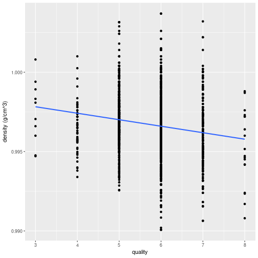

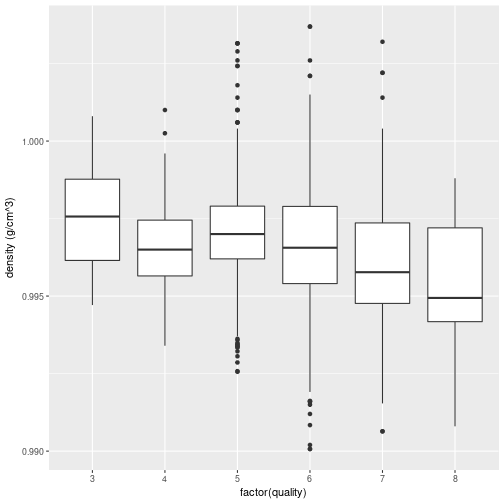

```
## $`3`
##    Min. 1st Qu.  Median    Mean 3rd Qu.    Max.
##  0.9947  0.9961  0.9976  0.9975  0.9988  1.0008
##
## $`4`
##    Min. 1st Qu.  Median    Mean 3rd Qu.    Max.
##  0.9934  0.9957  0.9965  0.9965  0.9974  1.0010
##
## $`5`
##    Min. 1st Qu.  Median    Mean 3rd Qu.    Max.
##  0.9926  0.9962  0.9970  0.9971  0.9979  1.0031
##
## $`6`
##    Min. 1st Qu.  Median    Mean 3rd Qu.    Max.
##  0.9901  0.9954  0.9966  0.9966  0.9979  1.0037
##
## $`7`
##    Min. 1st Qu.  Median    Mean 3rd Qu.    Max.
##  0.9906  0.9948  0.9958  0.9961  0.9974  1.0032
##
## $`8`
##    Min. 1st Qu.  Median    Mean 3rd Qu.    Max.
##  0.9908  0.9942  0.9949  0.9952  0.9972  0.9988
```

```
## [1] -0.1749192
```

No gráfico acima vemos que a densidade possui uma correlação negativa com a qualidade, em outras palavras os vinhos mais densos da amostra tendem a ter uma qualidade inferior

Vamos agora explorar a relação entre o pH e os três acidos contidos no dataframe.

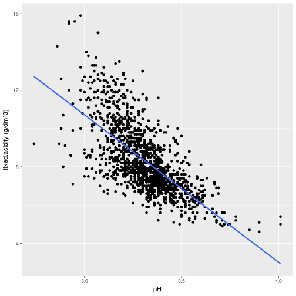

```
## [1] -0.6829782
```

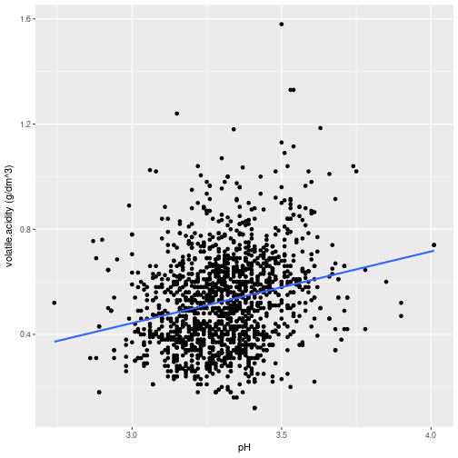

```
## [1] 0.2349373
```

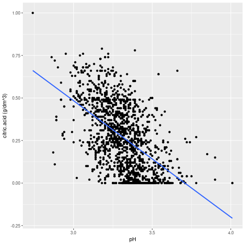

```
## [1] -0.5419041
```

Nestes gráficos fica evidente a forte correlação que existe entre o pH, e a concentração de cada um dos ácidos, principalmente entre o tartárico e cítrico. Como esperado o aumento da concentração dos ácidos tende a diminuir o pH, exceto o acético, que possivelmente possui um pH maior que 3.3, e eleva o valor do pH

Agora vamos verificar a correlação entre o alcool e a densidade, esperamos ver uma reta decrescente ja que a densidade do alcool é menos que a água

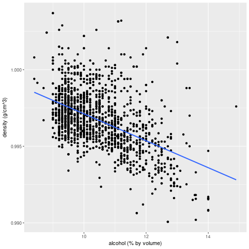

```
## [1] -0.4961798
```

A correlação entre a densidade de e o alcool é negativa, e as duas vizualizações apresentadas mostram esta tendência.

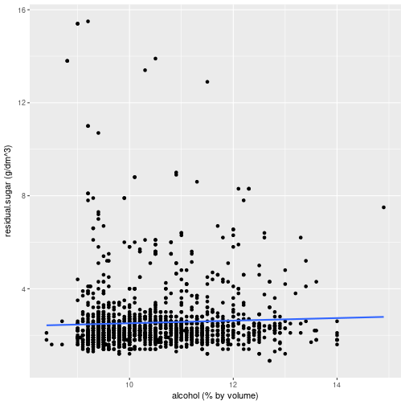

```
## [1] 0.04207544
```

Nesta correlação eu esperava verificar que quanto maior o o açucar residual menor o teor alcólico, devido o alcool presente no vinho ser resultante da fermentação, mas neste gráfico e pelo coeficiente vemos que não existe correlação entre as variáveis.

# Análise Bivariada

### Discuta sobre alguns dos relacionamentos observados nesta parte da investigação. Como os atributos de interesse variaram no conjunto de dados?

As variáveis de interesse analisadas foram a qualidade em relação ao alcool e densidade. Também analisamos a correlação entre o pH e a concentração dos ácidos contidos na amostra

Na primeira parte investigamos as correlações entre a qualidade, alcool e densidade. Estas duas variáveis são as que na etapa um eu especulei que teriam grande correlação com a qualidade do vinho, mas como podemos ver a partir dos coeficientes, nenhuma variável tem um coeficiente maior que 0.7 indicando grande correlação com a qualidade do vinho. O maior coeficiente encontrado foi o do alcool com 0.4761663, ja o coeficiente da densidade foi de -0.1749192.

Na segunda parte eu busquei investigar a correlação entre a concentração dos ácidos e o pH do vinho, aqui encontramos coeficientes relativamente altos de correlação, por exemplo o do ácido tartárico com o pH que apresentou um valor de -0.6829782. Aqui eu esperava encontrar apenas coeficientes negativos, ou seja quanto maior a concentração de ácido menor o pH, mas o coeficiente do ácido acético se apresentou positivo com um valor de 0.2349373, e minha hipótese para isto é que o pH do ácido acético é maior que 3.3 mas menor que 7, o que tende a aumentar o valor do pH

### Você observou algum relacionamento interessante entre os outros atributos (os que não são de interesse)?

As variáveis que não eram de interese mas foram analisadas foram a relação entre o alcool e densidade e também o açucar residual e teor alcólico

Na terceira parte eu analisei a correlação entre o alcool e a densidade, como o alcool possui uma densidade menor que a água a densidade tenderia a diminuir conforme o teor alcólico aumenta, e isto se reflete no coeficiente de correlação (-0.4961798)

Na quarta e ultima parte, eu desenhei um gráfico para verificar minha hipótese de que o açucar residual teria influência sobre o teor alcólico, mas como vemos a correlação apresentada foi de 0.04207544, uma valor que aponta que as duas variáveis não estão correlacionadas

### Qual foi o relacionamento mais forte encontrado?

O relacionamento mais forte foi o do ácido tartárico com o pH, apresentando um coeficiente de -0.6829782

# Seção de Gráficos Multivariados

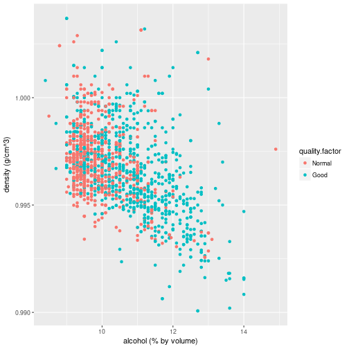

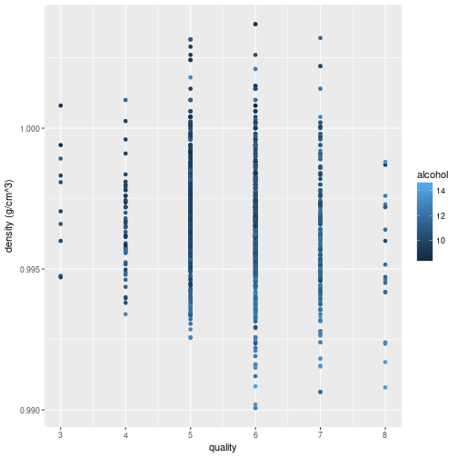

Nestes gráficos podemos explorar a relação entre a qualidade, teor alcólico e densidade do vinho

No primeiro gráfico podemos ver claramente a grande concentração de pontos vermelhos em densidades altas, e teor alcólico baixo. Ao aumentar o teor alcólico vemos que a densidade de pontos vermelhos diminui, e cresce a densidade de pontos azuis, indicando um aumento da qualidade do vinho

Ja no segundo gráfico é curioso observar os pontos para qualidade 5 e 7 comparar como a coluna para a qualidade 5 esta muito mais escura, que a qualidade 7.

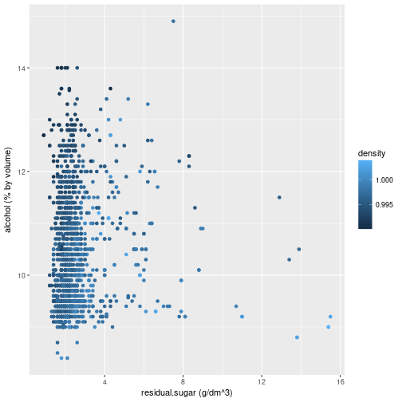

Neste gráfico podemos ver 2 relações, o escurecimento dos pontos com o aumento do teor alcólico e também o esclarecimento dos pontos com o aumento do açucar residual. Como sabemos a densidade afeta a qualidade do vinho, vamos observar o comportamento agora da densidade, açucar residual e qualidade

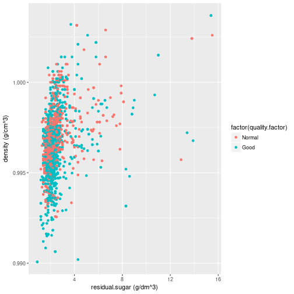

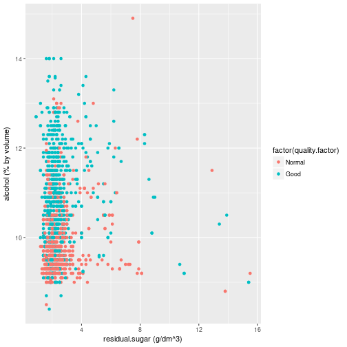

Aqui vamos olhar para 3 variáveis e como é a distribuição da qualidade ao longo delas.

Temos então no primeiro gráfico a densidade e açucar residual colorindo os vinhos de acordo com a qualidade. Neste gráfico fica claro a relação entre a densidade e qualidade e também entre o açucar residual e densidade, mas não vemos relação entre o açucar residual e qualidade

No segundo gráfico, podemos ver apenas a relação entre o teor alcólico e qualidade, mas nenhuma relação entre o açucar residual e qualidade ou teor alcólico

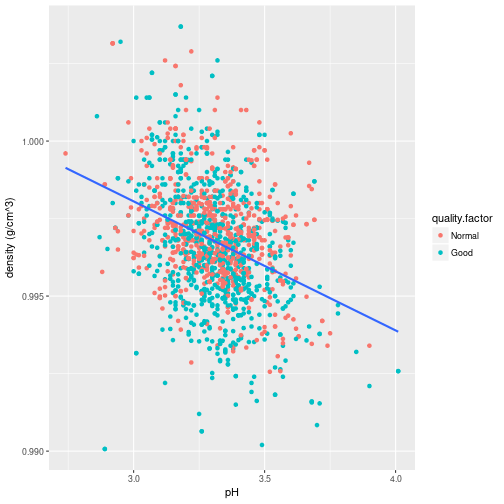

Aqui podemos ver a relação entre o pH e densidade, modelados pela reta e também a relação entre densidade e a qualidade, observando a densidade de pontos vermelhos acima da reta e pontos azuis abaixo da reta. Mas não podemos ver uam relação entre o pH e qualidade.

Vamos agora explorar a relação entre os ácidos colorido de acordo com o pH

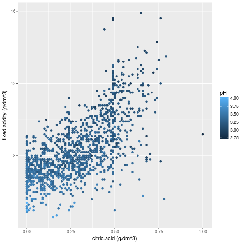

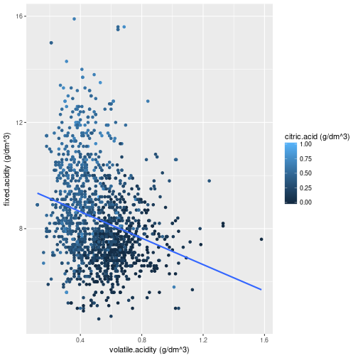

```
## [1] -0.2561309
```

Por ultimo um plot envolvendo as concetrações de cada ácido, e pelo incrível que pareça pelo que vemos no gráfico há uma relação entre as concentrações de cada ácido, o aumento do ácido acético tende a diminuir a concentração dos outros dois ácidos, a relaçaõ entre o ácido acético e tartárico esta modelada pela reta, e podemos ver o escurecimento dos pontos com o aumento do ácido acético indicando a diminuição da concentração do ácido cítrico.

# Análise Multivariada

### Discuta sobre os relacionamentos observados nesta parte da investigação. Quais atributos que fortaleceram os demais na observação das variáveis de interesse?

A principal vizualização que fortalece as observações anteriores é aquela que apresenta a relação entre densidade, teor alcólico coloridos pela qualidade. Nela fica evidente que o aumento da densidade leva a uma tendência na diminuição da qualidade, e o aumento do teor alcólico tende a aumentar a qualidade. Além da relação das variáveis com o teor alcólico vemos também que o aumento do teor alcólico tende a diminuir a densidade.

As outras observações, não nos levar a muitos novos insights sobre a relação das variáveis, apenas verificamos novamente que o açucar residual não tem influência na qualidade

### Interações surpreendentes e/ou interessantes foram encontradas entre os atributos?

A observação mais interessantes nesta última seção no meu ponto de vista foi a relação entre as concentrações dos três ácidos, que como podemos ver na última figura, o aumento do ácido acético, tende a diminuir a concentração dos outros dos ácidos. Achei muito curioso este fato.

Outra observação interessante, envolve também os ácidos, mas desta vez os relaciona com o pH, o aumento do ácido tatárico tende também a aumento o ácido cítrico, e como vemos na ilustração os pontos do gráfico que estão em região de grande concentração de ácido tartárico apresentam também um pH baixo

### OPCIONAL: Modelos foram criados usando este conjunto de dados? Discuta sobre os pontos fortes e as limitações do seu modelo.

# Gráficos Finais e Sumário

### Primeiro Gráfico

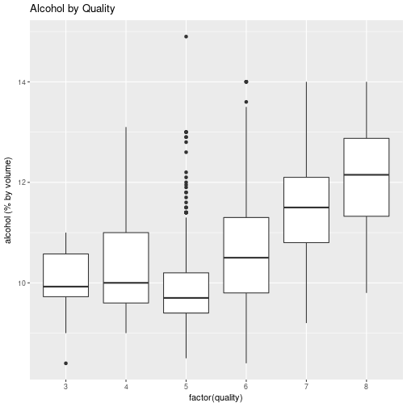

### Descrição do Primeiro Gráfico

Aqui noś podemos observar a distribuição do teor alcólico em relação a qualidade. Podemos ver que a maior concentração de outliers está nos vinhos com a qualidade 5, as duas variáveis plotadas provavelmente estão relacionadas. Com o aumento da qualiade vemos que o alcool também tende a aumentar.

Na parte de análise multivariada, vemos que a correlação existe e apresenta um coeficiente positivo de valor 0.4761663.

### Segundo Gráfico

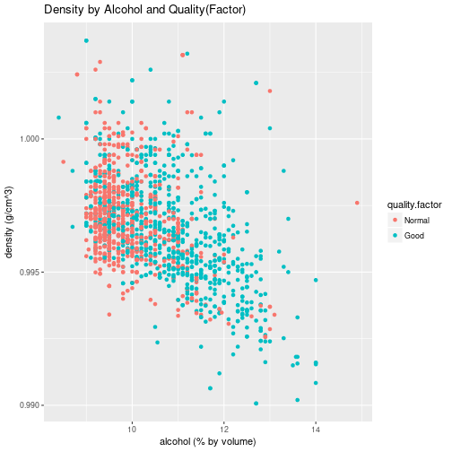

### Descrição do Segundo Gráfico

Aqui temos um plot das variáveis de interesse que eu acreditava que teriam grande impacto sobre a qualidade, os fatores de correlação apresentados do alcool em relação a qualidade foi de 0.4761663, e da densidade em relação a qualidade foi de -0.1749192. E como podemos ver no gráfico, além da relação das variáveis com a qualidade, as duas se relacionam entre si também com um coeficiente de correlação de -0.4961798.

As principais observaçõe sobre este gráfico, são os dois grupos distintos de pontos azuis e vermelhos, os vermelhos se posicionando em pontos de baixo teor alcólico e alta densidade, e os azuis em teores alcólicos altos e baixas densidades. Apresentando a correlação das duas variáveis com o a qualidade

### Terceiro Gráfico

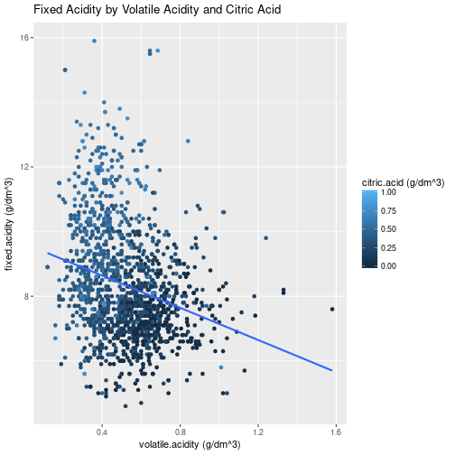

### Descrição do Terceiro Gráfico

Este foi o gráfico mais curioso no meu ponto de vista, para mim não haveria correlação entre as concentrações de cada um dos três ácidos, mas como podemos ver no gráfico e a partir dos coeficientes de correlação existe sim uma relação entre eles.

O que podemos ver claramente no gráfico, é que com o aumento do ácido acético a concentração dos outros dos ácidos tende a diminuir

# Reflexão

Para a primeira parte da análise dos dados eu busquei entender como os dados estavam organizadoss, as distribuições de cada uma das variáveis e unidades. O bando de dados é composto por 1599 observações de vinhos com 12 variáveis sendo analisadas. Inicialmente eu acreditava que a densidade, alcool e o pH teriam grande influência sobre a qualidade do vinho, mas durante o processo de análise bivariada, vi que o pH quase não tem influência sobre a qualidade do vinho, mas o alcool e densidade influênciam na qualiade. O primeiro possui um coefiente de correlação positivo moderado ja o segundo um coeficiente negativo fraco.

Além de analisar a relação das variáveis com a qualidade, eu busquei entender a relação dos ácidos com o pH, e um fato curioso é que o aumento do ácido acético tende a aumentar o pH do vinho.

Para os próximos passos é interessante montarmos um modelo preditivo, para estimarmos a qualidade do vinho baseado apenas nas variáveis do banco de dados, e também termos uma noção melhor de quais são os principais fatores que alteram a qualidade do vinho. Isto permitiria termos um noção prévia da qualidade do vinho, sem o auxílio de um degustador.